# IS580 - Term Project

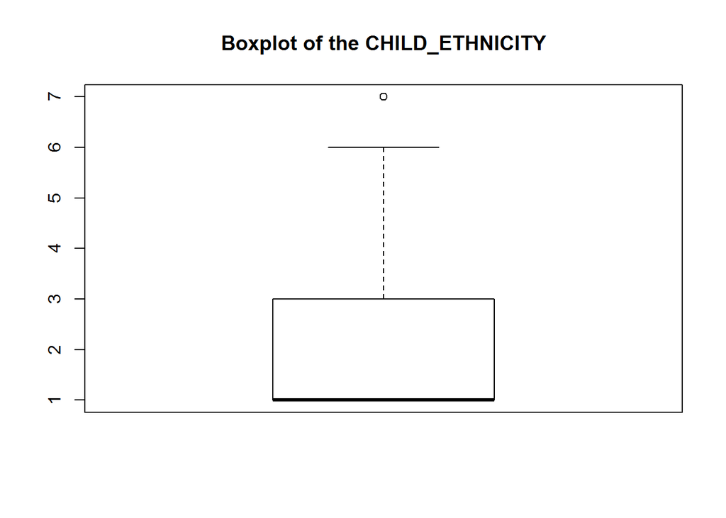

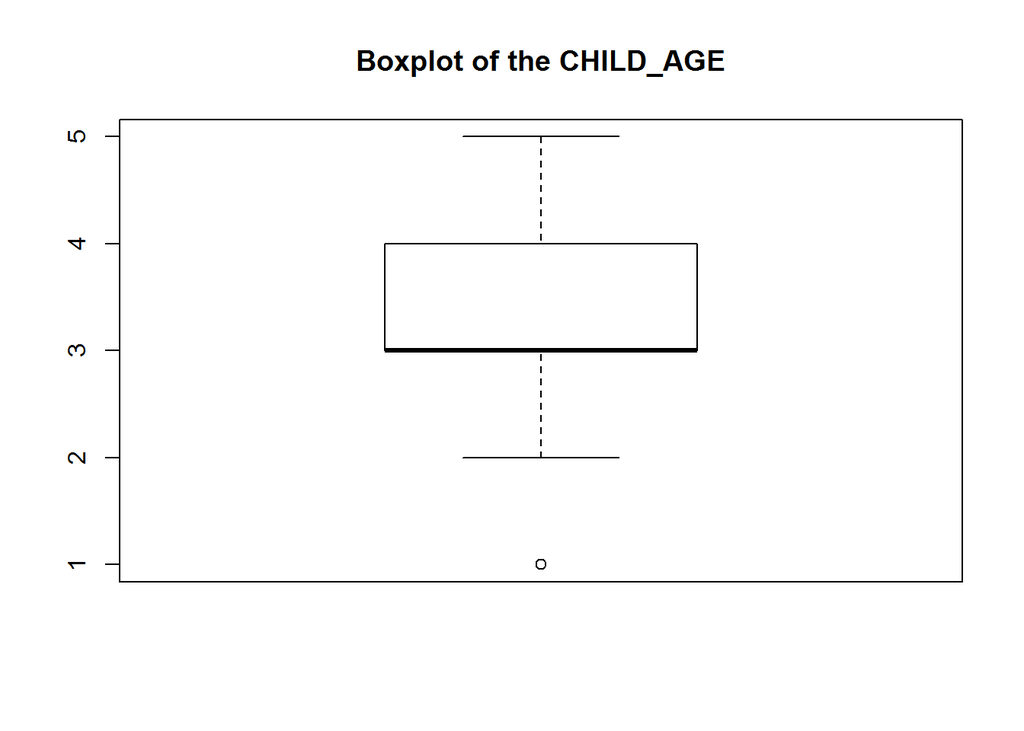

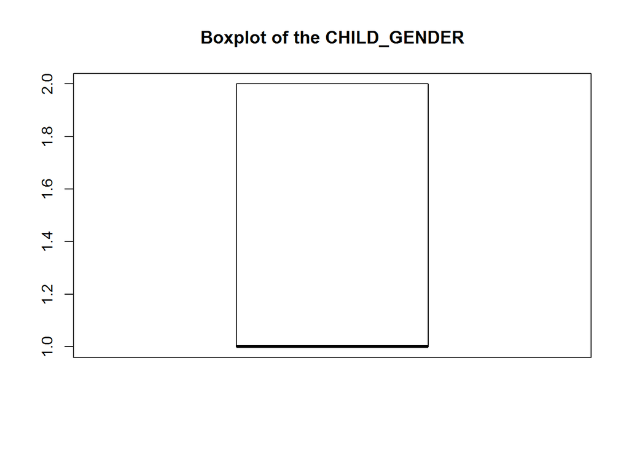

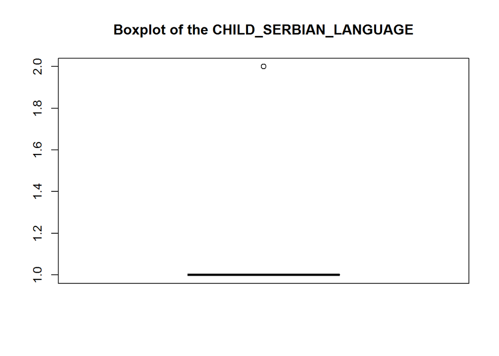

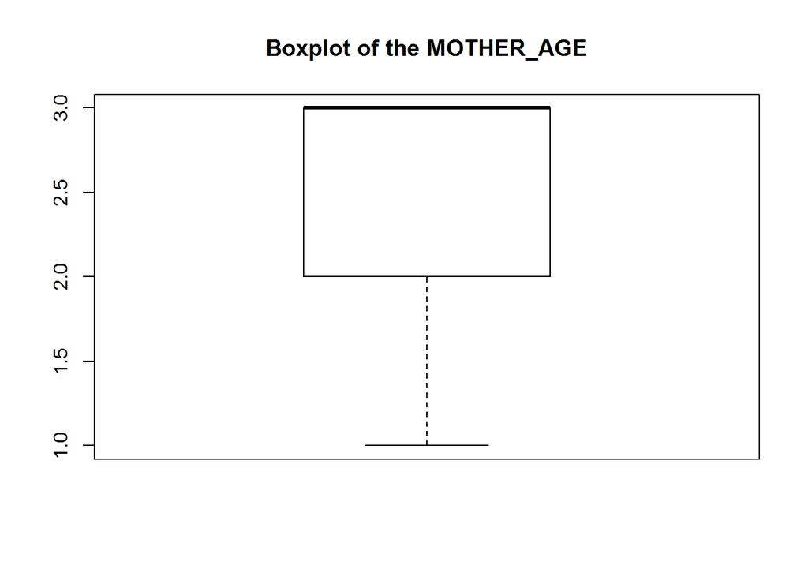

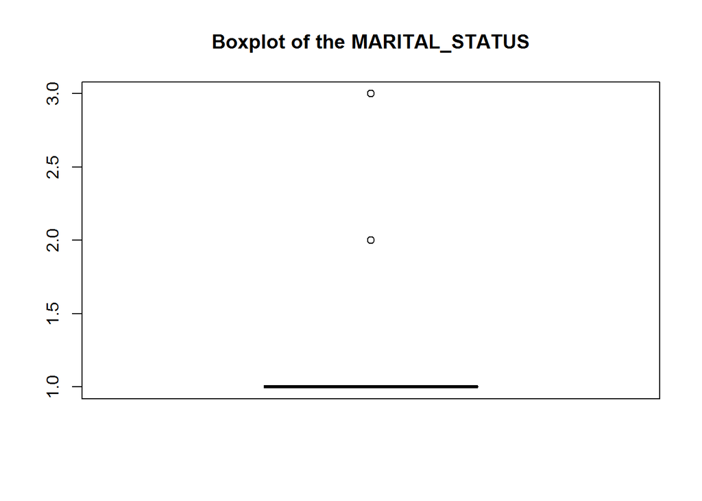

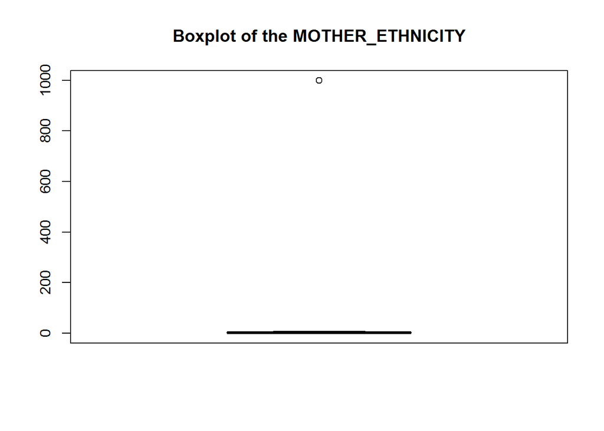

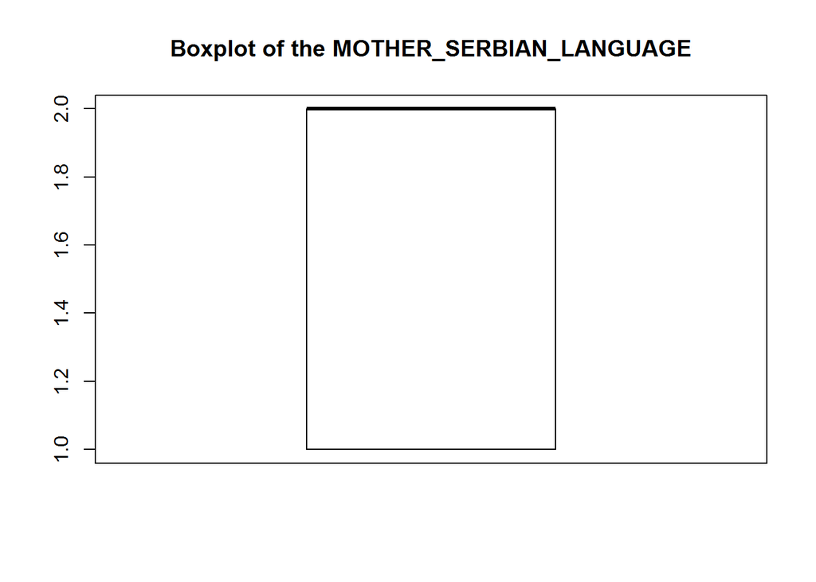

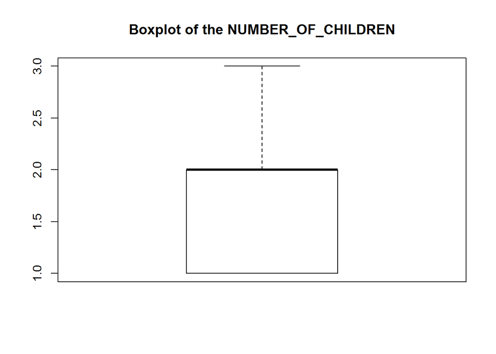

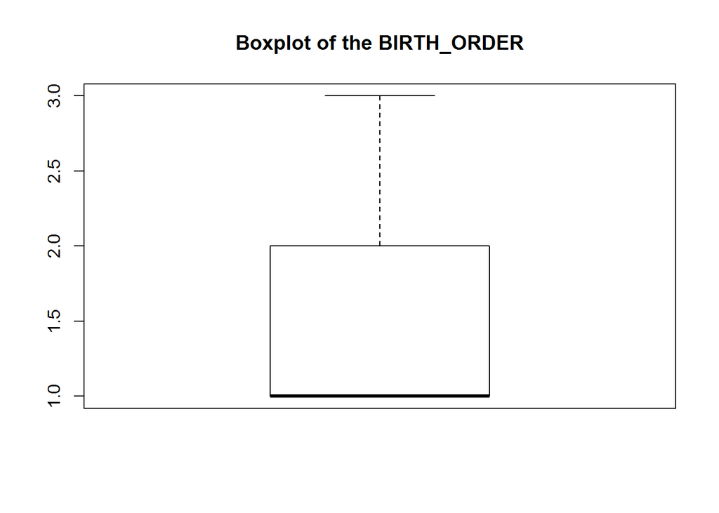

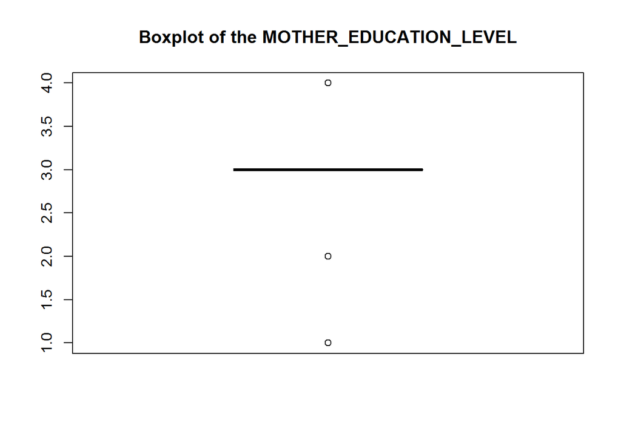

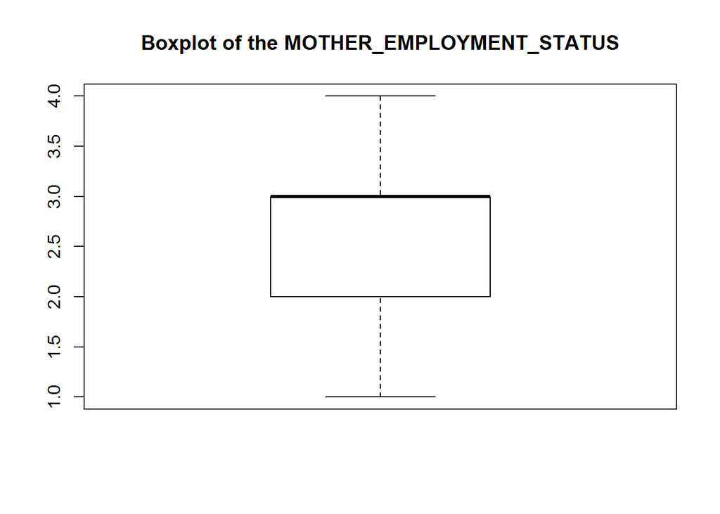

[23 more figures not shown]

```r
for (col in 2:ncol(TRAIN)) {
  boxplot(TRAIN[,col],main=paste("Boxplot of the",colnames(TRAIN)[col] ))
}
```

- All the boxplots were observed to have an opinion the outliers and their affects on the dataset analysis.

## 3. Classification Methods

```r
library(ade4)
library(data.table)

#COMBINE ALL DATA TO HAVE CONSISTENT
ALL_DATA <- rbind(TRAIN, VALIDATION, TEST)
ALL_DATA_x <- ALL_DATA[,1:35]
ALL_DATA_y <- ALL_DATA[36]

#APPLY ONE HOT METHOD TO CATEGORICAL AND NULL(999) INVOLVING FEATURES
col_names <- c("CITY", "CHILD_ETHNICITY", "MOTHER_ETHNICITY", "BREASTFEEDING_FREQUENCY", "BREASTFEEDING_DURING_NIGHT", "MOTHER_EMPLOYMENT_STATUS")
for (f in col_names){
  df_all_dummy = acm.disjonctif(ALL_DATA_x[f])
  ALL_DATA_x[f] = NULL
  ALL_DATA_x = cbind(ALL_DATA_x, df_all_dummy)
}

#DELETE .999 FEATURES
col_names999 <- c("MOTHER_ETHNICITY.999", "BREASTFEEDING_FREQUENCY.999", "BREASTFEEDING_DURING_NIGHT.999")
for (f in col_names999){
  ALL_DATA_x[f] = NULL
}



#NORMALIZATION FUNCTION
normalize <- function(x) {
  return ((x - min(x)) / (max(x) - min(x)))
}

#APPLY NORMALIZATION
ALL_DATA_x <- as.data.frame(lapply(ALL_DATA_x, normalize))
```

For ordered data

```r
ALL_DATA_x_o = ALL_DATA[,1:35]

factor_vars = c("CITY", "CHILD_ETHNICITY", "CHILD_GENDER", "MOTHER_SERBIAN_LANGUAGE",
                "CHILD_SERBIAN_LANGUAGE", "MARITAL_STATUS", "MOTHER_ETHNICITY")
ordered_vars = c("CHILD_AGE", "MOTHER_AGE", "BIRTH_ORDER",
                "MOTHER_EDUCATION_LEVEL", "MOTHER_EMPLOYMENT_STATUS", "QUALITY_OF_HOUSING",
                "HOUSING_CONDITIONS", "HOUSEHOLD_MONTHLY_INCOME",
                "BIRTH_WEIGHT", "BREASTFEEDING", "BREASTFEEDING_DURING_NIGHT",
                "BOTTLE_FEEDING", "INFANT_FORMULAS", "ADDITIONAL_FOOD_SWEETENING",
                "CHILD_FLUORIDE_SUPPLEMENTS", "CHILD_FLUORIDE_TOOTHPASTE", "CHILD_ORAL_HYGIENE",
                "CHILD_TOOTH_BRUSHING", "DIARRHEA_DURING_INFANCY", "MEDICAL_SYRUPS",
                "CHILD_FIRST_DENTIST_VISIT", "SWEETS_DURING_PREGNANCY",
                "FLUORIDE_SUPPLEMENTS_DURING_PREGNANCY", "ORAL_HEALTH_DURING_PREGNANCY",
                "MOTHER_HEALTH_AWARENESS", "FATHER_HEALTH_AWARENESS")

#ORDERED
for (var in ordered_vars) ALL_DATA_x_o[,var] = ordered(ALL_DATA_x_o[,var])
for (var in factor_vars) ALL_DATA_x_o[,var] = factor(ALL_DATA_x_o[,var])

#APPLY ONE HOT METHOD TO CATEGORICAL AND NULL(999) INVOLVING FEATURES
col_names <- c("CITY", "CHILD_ETHNICITY", "MOTHER_ETHNICITY", "BREASTFEEDING_FREQUENCY", "BREASTFEEDING_DURING_NIGHT", "MOTHER_EMPLOYMENT_STATUS")
for (f in col_names){
  df_all_dummy = acm.disjonctif(ALL_DATA_x_o[f])
  ALL_DATA_x_o[f] = NULL
  ALL_DATA_x_o = cbind(ALL_DATA_x_o, df_all_dummy)
}

#DELETE .999 FEATURES
col_names999 <- c("MOTHER_ETHNICITY.999", "BREASTFEEDING_FREQUENCY.999", "BREASTFEEDING_DURING_NIGHT.999")
for (f in col_names999){
  ALL_DATA_x_o[f] = NULL
}
```

### 3.1. Association Rule Mining (implemented on the paper)

```r
col_names <- colnames(TRAIN)
TRAIN_factor <- as.data.frame(lapply(TRAIN[,col_names], factor))

rules1 <- apriori(TRAIN_factor, appearance = list(rhs=c("ECC=1"), default="lhs"), parameter = list(minlen=2, maxlen=7, sup = 0.1, conf = 0.4, target="rules"))
```

```
## Apriori
##
## Parameter specification:
##  confidence minval smax arem  aval originalSupport maxtime support minlen
##         0.4    0.1    1 none FALSE            TRUE       5     0.1      2
##  maxlen target   ext
##       7  rules FALSE
##
## Algorithmic control:
##  filter tree heap memopt load sort verbose
##     0.1 TRUE TRUE  FALSE TRUE    2    TRUE
##
## Absolute minimum support count: 23
##
## set item appearances ...[1 item(s)] done [0.00s].
## set transactions ...[125 item(s), 239 transaction(s)] done [0.00s].
## sorting and recoding items ... [93 item(s)] done [0.00s].
## creating transaction tree ... done [0.00s].
## checking subsets of size 1 2 3 4 5 6 7
```

```
##  done [1.56s].
## writing ... [125 rule(s)] done [0.08s].
## creating S4 object  ... done [0.04s].
```

```r
rules1<-sort(rules1, decreasing=TRUE, by="confidence")
#inspect(rules1)

rules2 <- apriori(TRAIN_factor, appearance = list(rhs=c("ECC=2"), default="lhs"), parameter = list(minlen=2, maxlen=7, sup = 0.3, conf = 0.8, target="rules"))
```

```
## Apriori
##
## Parameter specification:
##  confidence minval smax arem  aval originalSupport maxtime support minlen
##         0.8    0.1    1 none FALSE            TRUE       5     0.3      2
##  maxlen target   ext
##       7  rules FALSE
##
## Algorithmic control:
##  filter tree heap memopt load sort verbose
##     0.1 TRUE TRUE  FALSE TRUE    2    TRUE
##
## Absolute minimum support count: 71
##
## set item appearances ...[1 item(s)] done [0.00s].
## set transactions ...[125 item(s), 239 transaction(s)] done [0.00s].
## sorting and recoding items ... [47 item(s)] done [0.00s].
## creating transaction tree ... done [0.00s].
## checking subsets of size 1 2 3 4 5 6 7
```

```
##  done [0.02s].
## writing ... [246 rule(s)] done [0.00s].
## creating S4 object  ... done [0.00s].
```

```r
rules2<-sort(rules2, decreasing=TRUE, by="confidence")
#inspect(rules2)
```

#### Justification for Model Parameters

- “rules1” is the rules obtained from the data set having ECC value of 1 at the right hand side with support value 0.1 and confidance value 0.4.
- “rules2” is the rules obtained from the data set having ECC value of 2 at the right hand side with support value 0.3 and confidance value 0.8.
- ECC dataset is unbalanced. As a result, when both ECC values are kept and rules are generated, dense part, which have ECC value of 2, dominates all obtained rules. When support and confidance values are kept low to obtain rules for both ECC values, Number of rules becomes a very large number. With above parameters, ~250 rules are generated for ECC=2 and ~120 rules are generated for ECC=1.

### 3.2. SVM

```r
#SEPARATE TRAIN, VALIDATION AND TEST
TRAIN_conv_x <- ALL_DATA_x[1:239,]
VALIDATION_conv_x <- ALL_DATA_x[240:273,]
TEST_conv_x <- ALL_DATA_x[274:341,]

TRAIN_y <- TRAIN[,36]
TRAIN_y <- as.factor(TRAIN_y)
VALIDATION_y <- VALIDATION[,36]
VALIDATION_y <- as.factor(VALIDATION_y)
TEST_y <- TEST[,36]
TEST_y <- as.factor(TEST_y)

#POSSIBLE COST AND GAMMA VALUES
cost_try = c(0.1, 0.5, 1, 5, 10, 20, 50, 80, 100, 500)
gamma_try = c(0.005, 0.01, 0.02, 0.05, 0.1, 0.5, 1, 2, 5, 10)

#BEST COST AND GAMMA VALUES SELECTED ACCORDING TO ACCURACY
max_accur = 0
best_cost = 1
best_gamma = 1
best_cost_index = 1
best_gamma_index = 1
svm_acc_res = matrix(0, 10, 10)
svm_sens_res = matrix(0, 10, 10)
svm_spec_res = matrix(0, 10, 10)
for (i in 1:10)
{
  for (j in 1:10)
  {
    svm_model <- svm(x = TRAIN_conv_x, y = TRAIN_y, gamma = gamma_try[j], cost = cost_try[i])
    svm_res <- predict(svm_model, VALIDATION_conv_x)
    conf_res <- confusionMatrix(svm_res, VALIDATION_y)

    if (max_accur < conf_res$overall[1])
    {
      max_accur = conf_res$overall[1]
      best_cost = cost_try[i]
      best_gamma = gamma_try[j]
      best_cost_index = i
      best_gamma_index = i
      print(conf_res$overall[1])
    }

    svm_acc_res[i,j] = conf_res$overall[1]
    svm_sens_res[i,j] = conf_res$byClass[1]
    svm_spec_res[i,j] = conf_res$byClass[2]
  }
}
```

```
##  Accuracy
## 0.6764706
##  Accuracy
## 0.7058824
##  Accuracy
## 0.7647059
```

```r
#BEST VALUES PRINTED
print(best_cost)
```

```
## [1] 5
```

```r
print(best_gamma)
```

```
## [1] 0.01
```

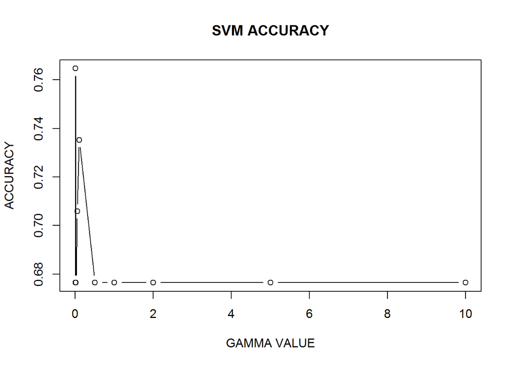

```r
#ACCURACY, SENSITIVITY AND SPECITIVITY are plotted
plot(gamma_try, svm_acc_res[best_cost_index, ], type = "b", main = "SVM ACCURACY", xlab = "GAMMA VALUE", ylab = "ACCURACY")
```

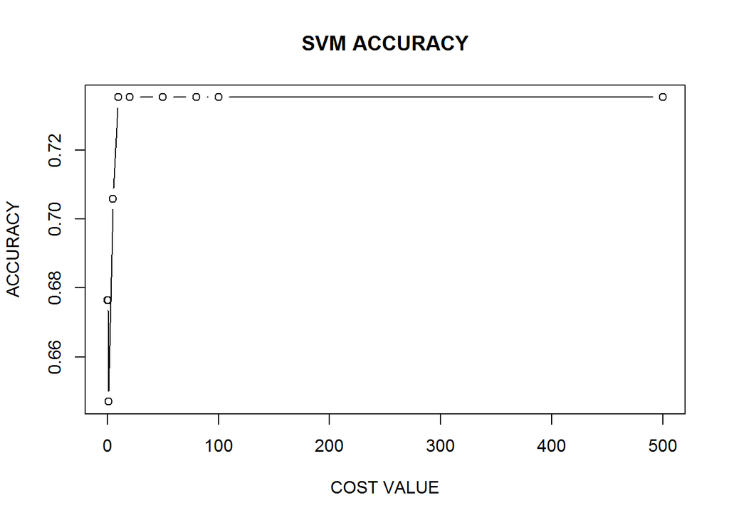

```r
plot(cost_try, svm_acc_res[ , best_gamma_index], type = "b", main = "SVM ACCURACY", xlab = "COST VALUE", ylab = "ACCURACY")
```

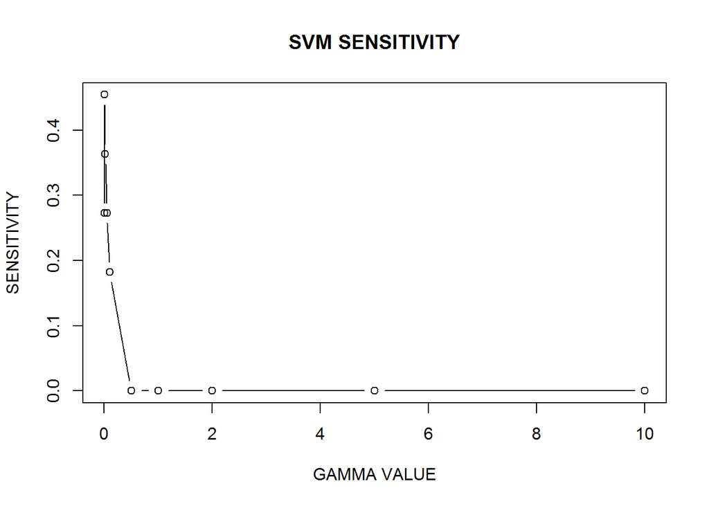

```r
plot(gamma_try, svm_sens_res[best_cost_index, ], type = "b", main = "SVM SENSITIVITY", xlab = "GAMMA VALUE", ylab = "SENSITIVITY")
```

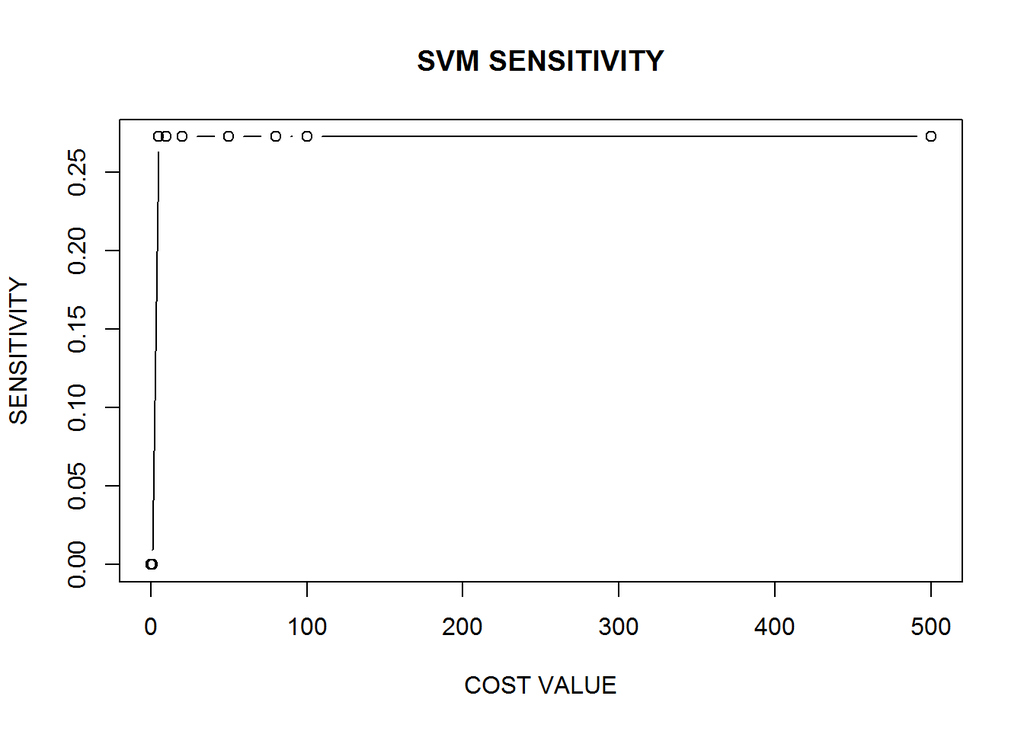

```r
plot(cost_try, svm_sens_res[ , best_gamma_index], type = "b", main = "SVM SENSITIVITY", xlab = "COST VALUE", ylab = "SENSITIVITY")
```

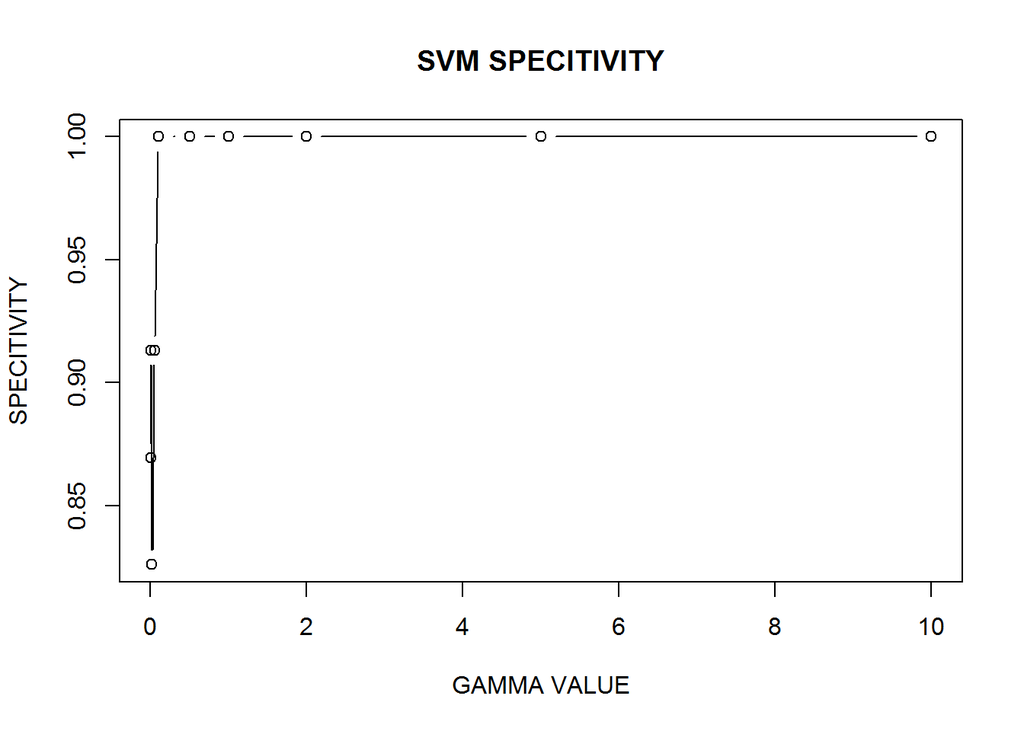

```r
plot(gamma_try, svm_spec_res[best_cost_index, ], type = "b", main = "SVM SPECITIVITY", xlab = "GAMMA VALUE", ylab = "SPECITIVITY")
```

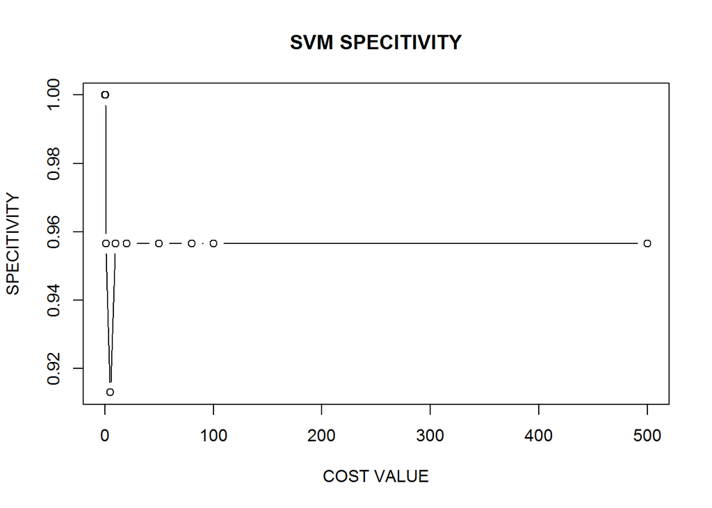

```r
plot(cost_try, svm_spec_res[ , best_gamma_index], type = "b", main = "SVM SPECITIVITY", xlab = "COST VALUE", ylab = "SPECITIVITY")
```

```r
#TEST DATASET IS PREDICTED AND RESULTS ARE DISPLAYED
svm_model <- svm(x = TRAIN_conv_x, y = TRAIN_y, gamma = best_gamma, cost = best_cost)
svm_res <- predict(svm_model, TEST_conv_x)
conf_res <- confusionMatrix(svm_res, TEST_y)
print(conf_res)
```

```
## Confusion Matrix and Statistics
##
##           Reference
## Prediction  1  2
##          1  5  2
##          2 17 44
##
##                Accuracy : 0.7206
##                  95% CI : (0.5985, 0.8227)
##     No Information Rate : 0.6765
##     P-Value [Acc > NIR] : 0.261543
##
##                   Kappa : 0.2236
##  Mcnemar's Test P-Value : 0.001319
##
##             Sensitivity : 0.22727
##             Specificity : 0.95652
##          Pos Pred Value : 0.71429
##          Neg Pred Value : 0.72131
##              Prevalence : 0.32353
##          Detection Rate : 0.07353
##    Detection Prevalence : 0.10294
##       Balanced Accuracy : 0.59190
##
##        'Positive' Class : 1
##
```

#### Justification for Model Parameters

- For the SVM model, Cost is how much we penalize the SVM for data points within the margin. If we decrease the cost, the error rate would increase where the margin gets larger. Gamma defines how far the influence of single training example reaches.
- If the value of Gamma is high, then our decision boundary will depend on points close to the decision boundary and nearer points carry more weights than far away points due to which our decision boundary becomes more wiggly.
- If the value of Gamma is low, then far away points carry more weights than nearer points and thus our decision boundary becomes more like a straight line.
- The value of gamma and C should not be very high because it leads to the overfitting or it shouldnâ€™t be very small (underfitting). Thus we need to choose the optimal value of C and Gamma in order to get a good fit. In our case, different costs and Gamma values were tried an adjusted for the best performance.

### 3.3. KNN

```r
#SEPARATE TRAIN, VALIDATION AND TEST
TRAIN_conv_x <- ALL_DATA_x[1:239,]
VALIDATION_conv_x <- ALL_DATA_x[240:273,]
TEST_conv_x <- ALL_DATA_x[274:341,]

TRAIN_y <- TRAIN[,36]
TRAIN_y <- as.factor(TRAIN_y)
VALIDATION_y <- VALIDATION[,36]
VALIDATION_y <- as.factor(VALIDATION_y)
TEST_y <- TEST[,36]
TEST_y <- as.factor(TEST_y)

#BEST K VALUE IS SELECTED ACCORDING TO ACCURACY
max_accur = 0
best_k_val = 1
knn_acc_res = vector()
knn_sens_res = vector()
knn_spec_res = vector()
for (i in 1:100)
{
  test_pred <- knn(train = TRAIN_conv_x, test = VALIDATION_conv_x, cl = TRAIN_y, k=i)
  conf_res <- confusionMatrix(test_pred, VALIDATION_y)

  if (max_accur < conf_res$overall[1])
  {
    max_accur = conf_res$overall[1]
    best_k_val = i
    print(conf_res$overall[1])
  }

  knn_acc_res[i] = conf_res$overall[1]
  knn_sens_res[i] = conf_res$byClass[1]
  knn_spec_res[i] = conf_res$byClass[2]
}
```

```
##  Accuracy
## 0.7058824
```

```r
#BEST VALUES PRINTED
print(best_k_val)
```

```
## [1] 1
```

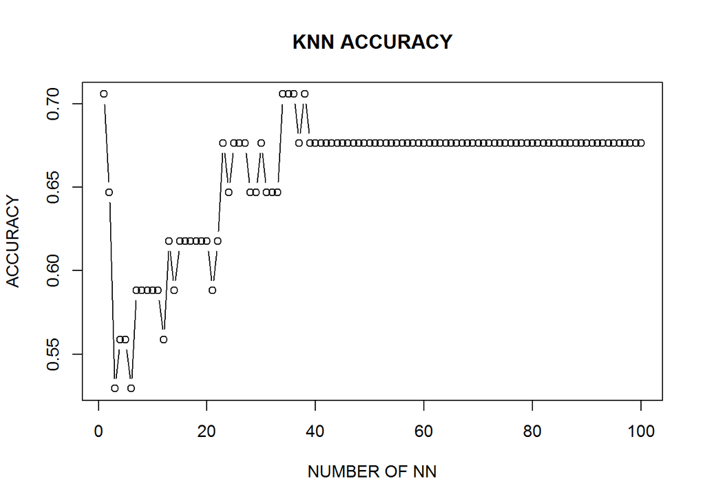

```r
#ACCURACY, SENSITIVITY AND SPECITIVITY are plotted
plot(1:100, knn_acc_res, type = "b", main = "KNN ACCURACY", xlab = "NUMBER OF NN", ylab = "ACCURACY")
```

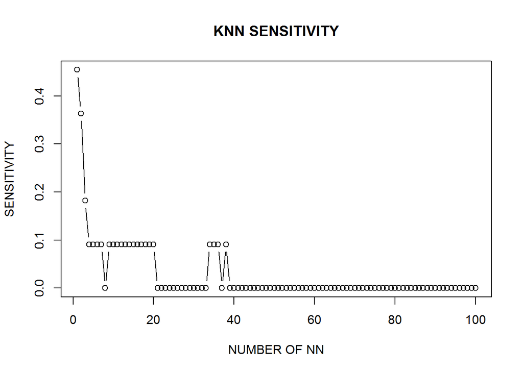

```r
plot(1:100, knn_sens_res, type = "b", main = "KNN SENSITIVITY", xlab = "NUMBER OF NN", ylab = "SENSITIVITY")
```

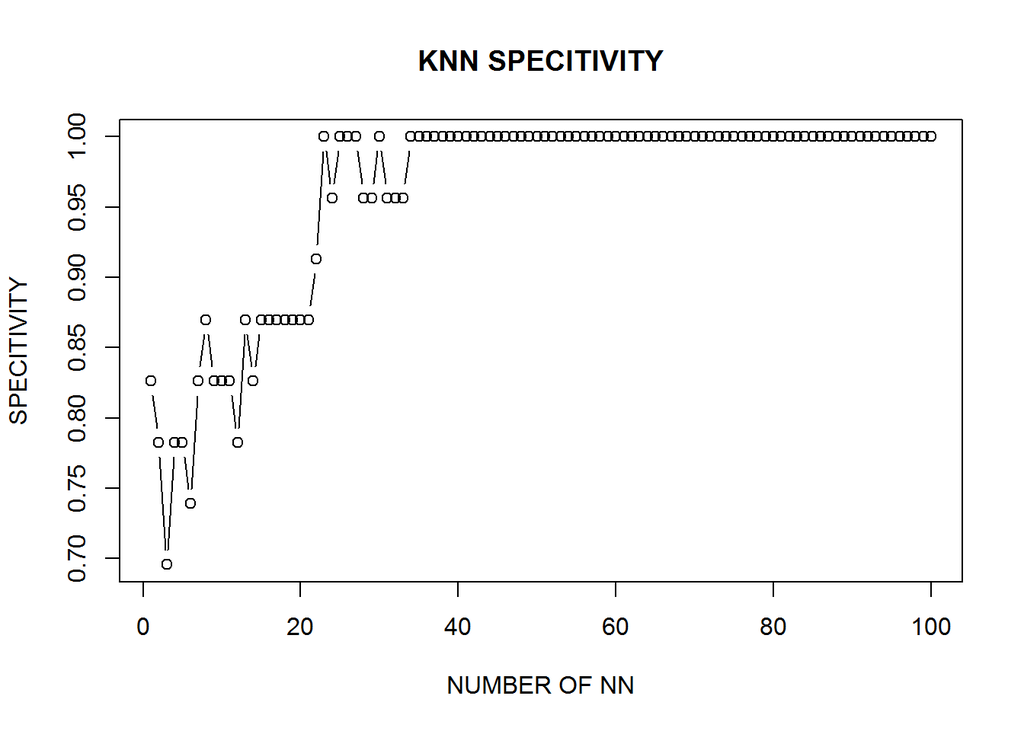

```r
plot(1:100, knn_spec_res, type = "b", main = "KNN SPECITIVITY", xlab = "NUMBER OF NN", ylab = "SPECITIVITY")
```

```r
#TEST DATASET IS PREDICTED AND RESULTS ARE DISPLAYED
test_pred <- knn(train = TRAIN_conv_x, test = TEST_conv_x, cl = TRAIN_y, k=best_k_val)
conf_res <- confusionMatrix(test_pred, TEST_y)
print(conf_res)
```

```
## Confusion Matrix and Statistics
##
##           Reference
## Prediction  1  2
##          1  8  7
##          2 14 39
##
##                Accuracy : 0.6912
##                  95% CI : (0.5674, 0.7976)
##     No Information Rate : 0.6765
##     P-Value [Acc > NIR] : 0.4545
##
##                   Kappa : 0.2306
##  Mcnemar's Test P-Value : 0.1904
##
##             Sensitivity : 0.3636
##             Specificity : 0.8478
##          Pos Pred Value : 0.5333
##          Neg Pred Value : 0.7358
##              Prevalence : 0.3235
##          Detection Rate : 0.1176
##    Detection Prevalence : 0.2206
##       Balanced Accuracy : 0.6057
##
##        'Positive' Class : 1
##
```

We also try KNN on the ordered dataset.

```r
#SEPARATE TRAIN, VALIDATION AND TEST
TRAIN_conv_x <- ALL_DATA_x_o[1:239,]
VALIDATION_conv_x <- ALL_DATA_x_o[240:273,]
TEST_conv_x <- ALL_DATA_x_o[274:341,]

TRAIN_y <- TRAIN[,36]
TRAIN_y <- as.factor(TRAIN_y)
VALIDATION_y <- VALIDATION[,36]
VALIDATION_y <- as.factor(VALIDATION_y)
TEST_y <- TEST[,36]
TEST_y <- as.factor(TEST_y)

#BEST K VALUE IS SELECTED ACCORDING TO ACCURACY
max_accur = 0
best_k_val = 1
knn_acc_res = vector()
knn_sens_res = vector()
knn_spec_res = vector()
for (i in 1:100)
{
  test_pred <- knn(train = TRAIN_conv_x, test = VALIDATION_conv_x, cl = TRAIN_y, k=i)
  conf_res <- confusionMatrix(test_pred, VALIDATION_y)

  if (max_accur < conf_res$overall[1])
  {
    max_accur = conf_res$overall[1]
    best_k_val = i
    print(conf_res$overall[1])
  }

  knn_acc_res[i] = conf_res$overall[1]
  knn_sens_res[i] = conf_res$byClass[1]
  knn_spec_res[i] = conf_res$byClass[2]
}
```

```
##  Accuracy
## 0.6176471
##  Accuracy
## 0.6470588
##  Accuracy
## 0.6764706
```

```r
#BEST VALUES PRINTED
print(best_k_val)
```

```
## [1] 39
```

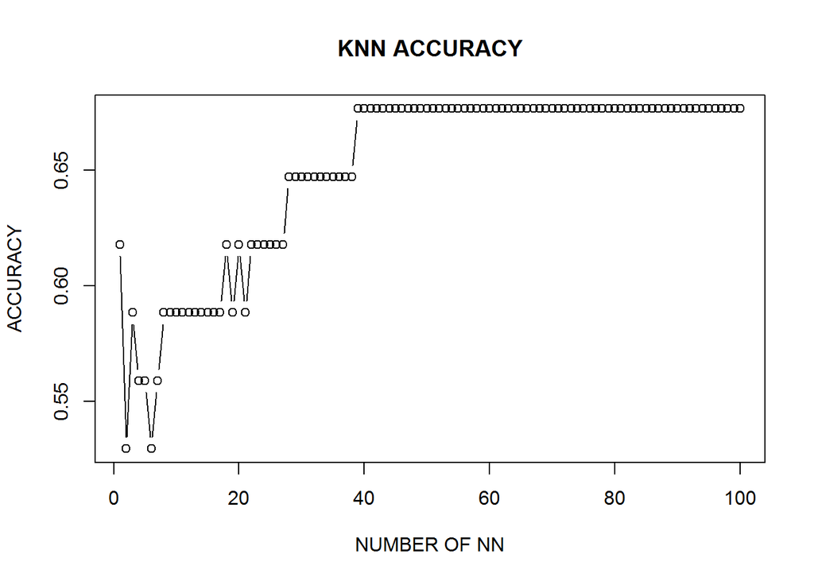

```r
#ACCURACY, SENSITIVITY AND SPECITIVITY are plotted
plot(1:100, knn_acc_res, type = "b", main = "KNN ACCURACY", xlab = "NUMBER OF NN", ylab = "ACCURACY")
```

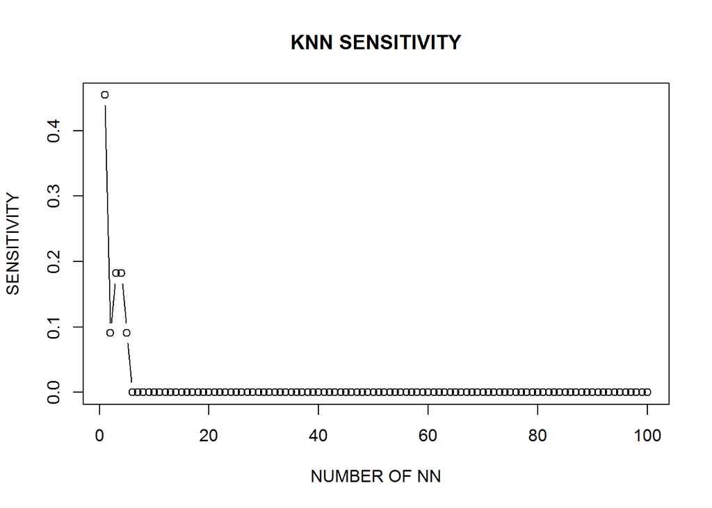

```r
plot(1:100, knn_sens_res, type = "b", main = "KNN SENSITIVITY", xlab = "NUMBER OF NN", ylab = "SENSITIVITY")
```

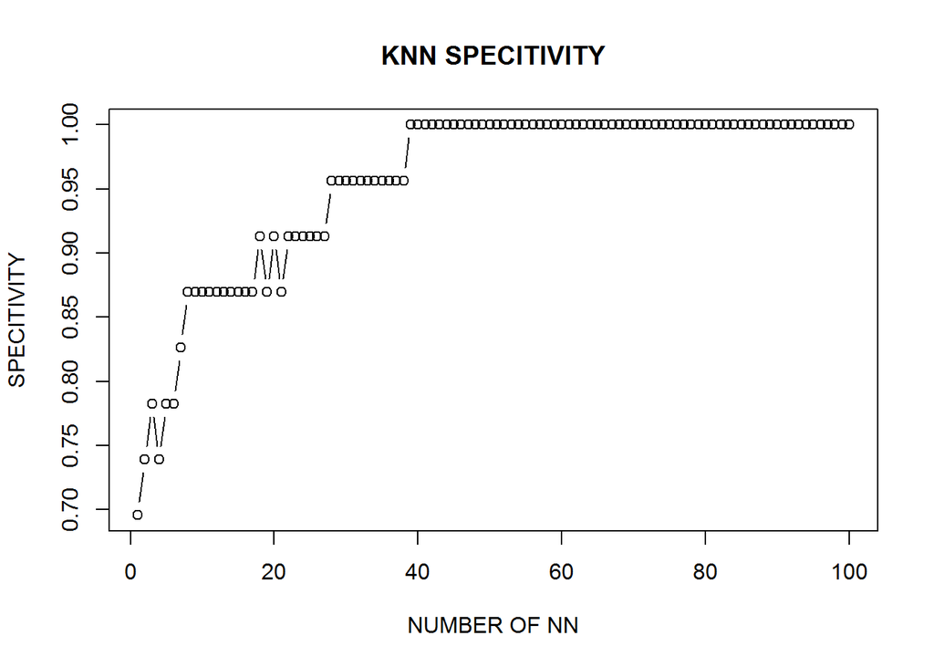

```r
plot(1:100, knn_spec_res, type = "b", main = "KNN SPECITIVITY", xlab = "NUMBER OF NN", ylab = "SPECITIVITY")
```

```r
#TEST DATASET IS PREDICTED AND RESULTS ARE DISPLAYED
test_pred <- knn(train = TRAIN_conv_x, test = TEST_conv_x, cl = TRAIN_y, k=best_k_val)
conf_res <- confusionMatrix(test_pred, TEST_y)
print(conf_res)
```

```
## Confusion Matrix and Statistics
##
##           Reference
## Prediction  1  2
##          1  0  0
##          2 22 46
##
##                Accuracy : 0.6765
##                  95% CI : (0.5521, 0.7849)
##     No Information Rate : 0.6765
##     P-Value [Acc > NIR] : 0.5575
##
##                   Kappa : 0
##  Mcnemar's Test P-Value : 7.562e-06
##
##             Sensitivity : 0.0000
##             Specificity : 1.0000
##          Pos Pred Value :    NaN
##          Neg Pred Value : 0.6765
##              Prevalence : 0.3235
##          Detection Rate : 0.0000
##    Detection Prevalence : 0.0000
##       Balanced Accuracy : 0.5000
##
##        'Positive' Class : 1
##
```

#### Justification for Model Parameters

- For the KNN model, the most and only important parameter is the ‘k value’. it looks through the training data and finds the k training examples that are closest to the new example. It then assigns the most common class label (among those k training examples) to the test example.
- When the data is directly fed to the model, we observed that k=1 gives the best results within all k values. Normally, k=1 might show the appearance of overfitting. But in our case, it does not. As our class labels are nominal and have small number of types, 1-NN does not directly show overfitting.
- Also, we tried this model for the ordered (nominal) dataset. The optimal k value is not 1 but equal to 39 in this case. But the accuracy result did not change surprisingly.

### 3.4. Naive Bayesian

```r
#SEPARATE TEST
TEST_conv_x <- ALL_DATA_x[274:341,]
TEST_y <- TEST[,36]
TEST_y <- as.factor(TEST_y)

#VALIDATION COMBINED WITH TRAIN
TV_conv_x <- ALL_DATA_x[1:273,]
TV_y <- c(TRAIN_y, VALIDATION_y)
TV_y <- as.factor(TV_y)

#BECAUSE OF NO PARAMETER SELECTION, NB APPLIED DIRECTLY
nb_model <- naiveBayes(x = TV_conv_x, y = TV_y, laplace = laplace)
nb_res <- predict(nb_model, TEST_conv_x)
conf_res <- confusionMatrix(nb_res, TEST_y)
print(conf_res)
```

```
## Confusion Matrix and Statistics
##
##           Reference
## Prediction  1  2
##          1 15 28
##          2  7 18
##
##                Accuracy : 0.4853
##                  95% CI : (0.3622, 0.6097)
##     No Information Rate : 0.6765
##     P-Value [Acc > NIR] : 0.9996453
##
##                   Kappa : 0.0585
##  Mcnemar's Test P-Value : 0.0007232
##
##             Sensitivity : 0.6818
##             Specificity : 0.3913
##          Pos Pred Value : 0.3488
##          Neg Pred Value : 0.7200
##              Prevalence : 0.3235
##          Detection Rate : 0.2206
##    Detection Prevalence : 0.6324
##       Balanced Accuracy : 0.5366
##
##        'Positive' Class : 1
##
```

#### Justification for Model Parameters

- Naive Bayesian is the simplest classification algorithm we used. And it does not have any special parameters to be justified. From the results, this model gives low accuracy and high sensitivity.

### 3.5. Random Forest

```r
#SEPARATE TRAIN, VALIDATION AND TEST
TRAIN_conv_x <- ALL_DATA_x[1:239,]
VALIDATION_conv_x <- ALL_DATA_x[240:273,]
TEST_conv_x <- ALL_DATA_x[274:341,]

TRAIN_y <- TRAIN[,36]
TRAIN_y <- as.factor(TRAIN_y)
VALIDATION_y <- VALIDATION[,36]
VALIDATION_y <- as.factor(VALIDATION_y)
TEST_y <- TEST[,36]
TEST_y <- as.factor(TEST_y)

#BEST NTREE VALUE IS SELECTED ACCORDING TO ACCURACY
max_accur = 0
res_num_of_tree = 0
num_of_tree = 16
rf_acc_res = vector()
rf_sens_res = vector()
rf_spec_res = vector()
for (i in 1:7)
{
  set.seed(97)

  rf_model <- randomForest(x = TRAIN_conv_x, y = TRAIN_y, ntree = num_of_tree)
  rf_res <- predict(rf_model, VALIDATION_conv_x)
  rf_res_round <- as.factor(round(as.numeric(rf_res)))
  conf_res <- confusionMatrix(rf_res_round, VALIDATION_y)

  if (conf_res$overall[1] > max_accur)
  {
    max_accur = conf_res$overall[1]
    res_num_of_tree = num_of_tree
    print(conf_res$overall[1])
  }

  rf_acc_res[i] = conf_res$overall[1]
  rf_sens_res[i] = conf_res$byClass[1]
  rf_spec_res[i] = conf_res$byClass[2]

  num_of_tree = num_of_tree*2
}
```

```
##  Accuracy
## 0.5882353
##  Accuracy
## 0.6470588
##  Accuracy
## 0.6764706
```

```r
#BEST VALUES PRINTED
print(res_num_of_tree)
```

```
## [1] 64
```

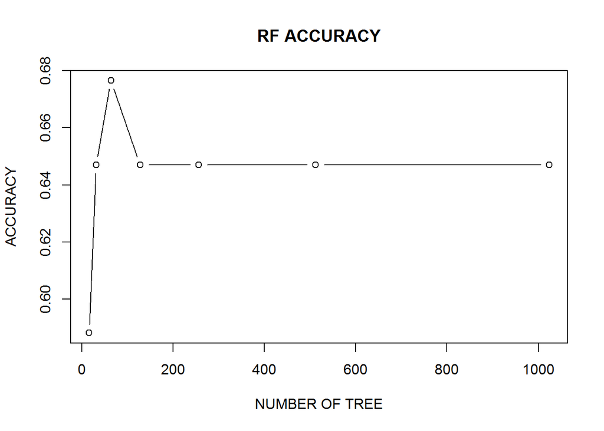

```r
plot(2^(4:10), rf_acc_res, type = "b", main = "RF ACCURACY", xlab = "NUMBER OF TREE", ylab = "ACCURACY")
```

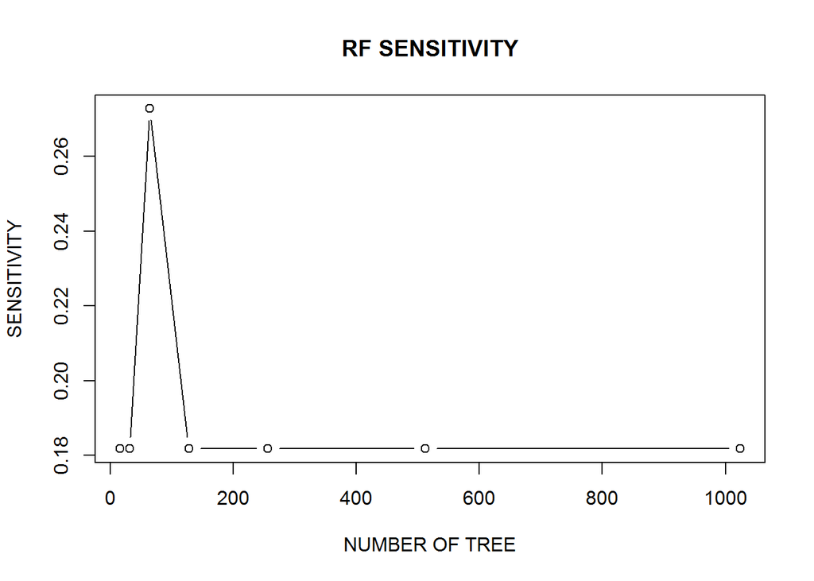

```r
plot(2^(4:10), rf_sens_res, type = "b", main = "RF SENSITIVITY", xlab = "NUMBER OF TREE", ylab = "SENSITIVITY")
```